# Extreme Weather Trends Explained

author: Bebe Phornprapha date: September 20th autosize: true

# Historical Development

- Definition: Extreme weather includes unexpected, unusual, unpredictable severe or unseasonal weather.
- Examples include flooding, heat waves, droughts, and hurricanes
- These events have been happening since the beginning of time
- However, over the last 50 years, NOAA reports that much of the U.S. has seen increases in prolonged periods of excessively high temperatures, heavy downpours, and in some regions, severe floods and droughts.
- An increase in temperature has caused an increase of water vapor in the atmosphere, which will lead to a change in the atmospheric circulation. Warmer temperatures won’t just inspire dryer soils leading to droughts and heat waves, but also it can lead to an increase in water vapor in the atmosphere, leading to extreme rainfall events, flooding, and storms.

# Data sources, and methods of analysis

[figure not shown]

Mauna loa

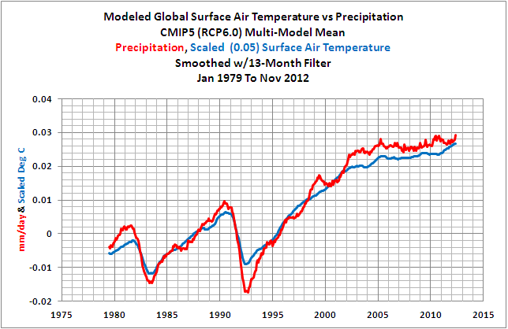

precipitation

# Areas of Uncertainty

- Extreme climate events have been happening throughout history, and humans were not around then to have recorded such events.
- A single natural hazard cannot be directly linked to global warming.
- Lack of extreme weather events, such as that there have been longer winters and that there has been no major hurricanes since 2005.

# Politicization of Evidence

- Senator Jim Inhofe has argued that “god, not humans control the weather” and has pushed for the blocking of carbon regulation.
- Positive effects of some natural disasters to commemorate extreme weather events

# Conclusion

- Due to the recorded evidence of global temperature increase and the correlation between frequency and intensity of extreme weather trends, it can be deduced that human induced global warming is the cause, and that this trend will continue if the world continues to get warmer.
- The only way to quell the extremity of the weather trends is to curb carbon emissions, as this will decrease the enhanced greenhouse effect and make the earth cooler and less susceptible to the extreme weather trends.